# Part II - Loan Data from Prosper Analysis

## by Nosakhare Imasuen

## Dataset Overview

> There are 113,937 loans in this data collection, each containing factors such as loan amount, borrower rate (or interest rate), current loan status, borrower income, and more. The data set can simply be described to contain data about the individual (borrower) and details about the loan in service.

> The primary goals of this project is to describe the features of factors that might impact loan status and to get some insight into the interactions between numerous variables by utilizing summary statistics and data visualizations.

## BorrowerAPR Distribution

> As observed, the lowerest BorrowerAPR is at around 0.06% and the highest is at around 0.42%. There are three visible spike around 0.17, 0.29 and 0.36.

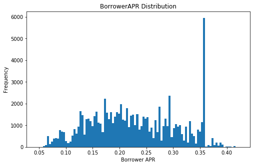

## CurrentCreditLines VS BorrowerAPR

> The regression line in a scatter plot showing a negative correlation between the two variables. The higher the CurrentCreditLines, the lesser the BorrowerAPR

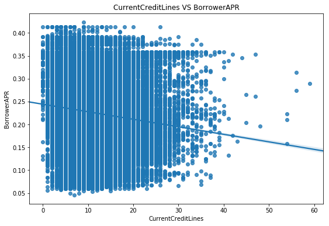

## MonthlyLoanPayment VS BorrowerAPR

> There's a negative correlation between Monthly loan payment and BoerrowerAPR. This makes sense because the higher the monthly loan payment the lower the BorrowerAPR.

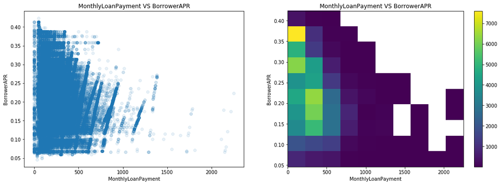

## ProsperRating (Alpha) VS BorrowerAPR

> There is a negative correlation between ProsperRating and BorrowerAPR. ProsperRating has an influence or impact on the percentage of the borrowerAPR. The better the Prosper Rating the lesser the BorrowerAPR.

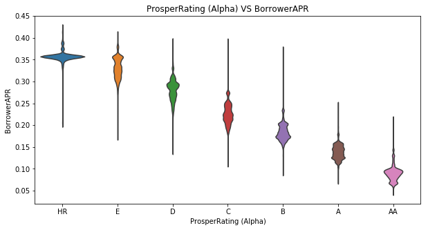

## IncomeRange VS MonthlyLoanPayment VS Term

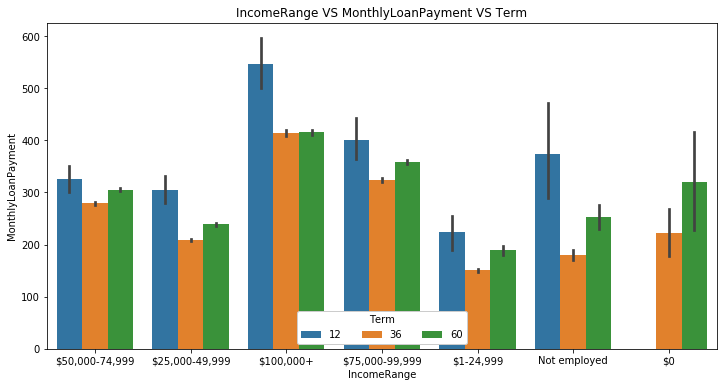